**POL S/CS&SS 501, University of Washington, Spring 2015**

# Introduction to R and RStudio with Gapminder

Jeffrey B. Arnold

January 7, 2015

1. Use the RStudio IDE to run R scripts
2. Setup an RStudio Project
3. Install and load an R package
4. Use R functions and help pages to explore the `gapminder` dataset and find the number of rows, columns, names, and descriptions of the data frame.
5. Use `ggplot2` to create histograms and scatter plots of the `gapminder` data

# Orientation with RStudio

R is the name of the programming language, and RStudio is a convenient and widely used interface to that language.

Since you will be using it for the remainder of the course, you should familiarize yourself with the RStudio GUI.

It consists of four windows,

1. Bottom left: The **console** window. You type commands at the `>` prompt and R executes them.
2. Top left: The **editor** window. Here you can edit and save R scripts which contain multiple R commands.
- You can open a new R script using *File -> New -> R script*.
- If you highlight an area, you can run those commands in the console with the “Run” button.
- You can run all the commands in the **editor** window using the “Source” button.
3. Top right
- **workspace** lists all R objects (variables) that are defined
- **history** lists all the commands that have been typed into the console.
4. Bottom right
- **files** allows you to browse directories and open files.
- **plots** displays any plots created. In this window you can toggle back through previously created plots.
- **packages** shows which packages are installed and loaded.
- **help** displays R help.

RStudio documentation can be found at https://support.rstudio.com/hc/en-us/categories/200035113-Documentation. Of those, the most likely to be useful to you are:

- [Working in the Console](https://support.rstudio.com/hc/en-us/articles/200404846-Working-in-the-Console)
- [Editing and Executing Code](https://support.rstudio.com/hc/en-us/articles/200484448-Editing-and-Executing-Code)
- [Viewing Command History](https://support.rstudio.com/hc/en-us/articles/200526217-Command-History)

**Challenge:**

1. Go to *Tools > Global Options*. Change the font and color of the editor and console. Which one do you like the best?
2. What happens when you type `Alt+Shift+K`?

# Variables and the Environment

In R, you can save the results of calculations into objects that you can use later. This is done using the special symbol, `<-`. For example, this saves the results of 2 + 2 to an object named `foo` [^1]

```r
foo <- 2 + 2
```

You can see that `foo` is equal to `4`

```r
foo
```

```
## [1] 4
```

And you can reuse foo in other calculations,

```r
foo + 3
```

```
## [1] 7
```

```r
foo / 2 * 8 + foo
```

```
## [1] 20
```

You can use `=` instead of `<-` for assignment. You may see this in some other code. There are some technical reasons to use `<-` instead of `=`, but the primary reason we will use `<-` instead of `=` is that this is the convention used in modern `R` programs.

# Working Directory and R Projects

## R Projects

Keeping all the files associated with a project organized together – input data, R scripts, analytic results, figures – is such a wise and common practice that RStudio has built-in support for this via its projects. Read [this](https://support.rstudio.com/hc/en-us/articles/200526207-Using-Projects) for more information about RStudio projects.

You will use RStudio projects for your labs and homework, and **final paper**. Create a RStudio project that you will use for all this lab.

1. *File -> New Project*
2. Select “New Directory”
3. Select “Empty Project”
4. Select a name for your project as Directory Name. “pols_501_lab01” is as good as any, and better than most. Choose where to put this directory with “Create project as sub-directory of”. Do not worry about the other options.

# Creating your first R script

# Gapminder Data

We will use a dataset from the **gapminder**.

The gapminder package is not installed with R by default, so you need to install it using `install.package`.

```r
install.packages("gapminder")
```

After installing the package, you need to load it using the `library` function in order to be able to access the functions and data in it.

```r
library("gapminder")
```

We find out what is in the gapminder dataset using the help function

```r
help(package = "gapminder")
```

The **gapminder** package includes a couple of datasets. This package contains country-level data from [Gapminder.org](http://www.gapminder.org) on income and life expectancy. This [Ted Talk](https://www.ted.com/talks/hans_rosling_shows_the_best_stats_you_ve_ever_seen) by Hans Rosling is one of the better data visualization talks out there.

The dataset that we are interested in is `gapminder`. You can read the help for this dataset by clicking on the link for it or using the `help` function

```r
help("gapminder")
```

Load the dataset into your environment using the `data` function. Note that currently `data` is not in the environment

```r
ls()
```

```
## [1] "foo"
```

Now load `gapminder` using `data()`,

```r
data("gapminder")
```

You will not see a message if this is successful. However, there will be an object called `gapminder` into the environment,

```r
ls()
```

```
## [1] "foo"       "gapminder"
```

The `gapminder` object is a *data frame*. A data frame is a type of R object that corresponds to what you usually think of as a dataset or a spreadsheet — rows are observations and columns are variables.

**Challenge:** What happens when you do the following?

```r
gapminder
```

This is a lot of information. How can we get a more useful picture of the dataset as a whole?

```r
dim(gapminder)
names(gapminder)
head(gapminder)
tail(gapminder)
summary(gapminder)
```

- `dim` shows the dimensions of the data frame as the number of rows, columns
- `names` shows the column names of the data frame.
- `head` shows the first few observations
- `tail` shows the last few observations
- `summary` calculates summary statistics for all variables in the data frame.

**Challenge:** Given the information previously:

1. What are the variables in the dataset?
2. How many observations are there?
3. What is the unit of observation?
4. What types of data are the different variables?
5. What is the range of years in the data?
6. What are the mean and median life expectancy?

# Working with variables in Data Frames

You can extract single variables (columns) and perform different operations on them.

To extract a variable, we use the dollar sign (`$`) extraction operator.

```r
gapminder$lifeExp
```

Alternatively use double-brackets.

```r
gapminder[["lifeExpr"]]
```

Again, perhaps a summary may be more interesting. We can do more specific operations on this variable alone:

```r
mean(gapminder$lifeExp)
median(gapminder$lifeExp)
min(gapminder$lifeExp)
max(gapminder$lifeExp)
```

We can add variables to the data frame using `<-`

```r
gapminder$log_life_exp <- log(gapminder$lifeExp)
gapminder$log_gdp_per_cap <- log(gapminder$gdpPercap)
```

You can extract specific columns and rows using the bracket operators.

**Challenge:** Run each of the following lines. What does each do?

```r
gapminder[["year"]]
gapminder[ , "year"]
gapminder[1, ]
gapminder[1:5, ]
gapminder[c(1, 10, 20), ]
gapminder[, 1:2]
gapminder[ , "year"]
gapminder[ , c("year", "country")]
gapminder[1:5, c("year", "country")]
gapminder[["year"]][1:5]
gapminder[gapminder$year == 2007, ]
gapminder[gapminder$year == 2007, c("country", "year", "lifeExp")]
gapminder[gapminder$year == 2007, ][ , c("country", "year", "lifeExp")]
gapminder[gapminder$year == 2007, ]$lifeExp
gapminder[gapminder$country == "United States", ]
gapminder[gapminder$country == "United States",
          c("year", "gdpPercap", "lifeExp")]
gapminder[gapminder$country == "United States",
          c("year", "gdpPercap", "lifeExp")]
gapminder[gapminder$country == "United States" & gapminder$year == 2007, ]
gapminder[gapminder$country == "United States" | gapminder$year == 2007, ]
gapminder[gapminder$country %in% c("United States", "France", "Germany"), ]
gapminder[gapminder$country %in% c("United States", "France", "Germany") &
            gapminder$year == 2007, ]
gapminder[gapminder$country %in% c("United States", "France", "Germany") &
            gapminder$year > 2000, ]
gapminder[gapminder$country %in% c("United States", "France", "Germany") &
            gapminder$year %in% c(2000, 2007), ]
```

**Challenge**

1. What are the mean and median of GDP per capita?
2. Find the 30th percentile of GDP per capita?
3. The function `length()` calculates the length of a vector. The function `unique()` returns the number of unique values in a vector. How many countries in the data are there? How many years?

# Creating Plots with `ggplot2`

Summary statistics reduce the information of a distribution to single values. A distribution provides a richer understanding of the data. Look at the distribution of the variable `lifeExp`.

You will use the **ggplot2** package for graphics for most of this course. In order to use it, you will need to load it using `library()`

```r
library("ggplot2")
```

Create a histogram:

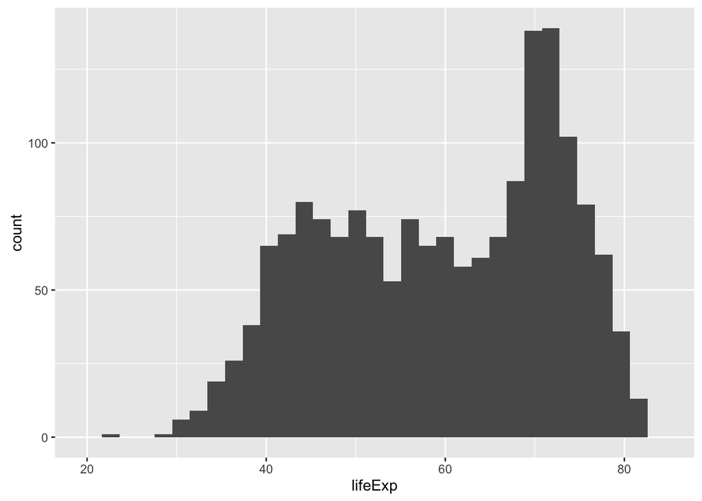

```r
ggplot(gapminder, aes(x = lifeExp)) +
  geom_histogram()
```

Note that this gives a message asking the user to choose a binwidth. We can solve that by adding a binwidth argument to `geom_histogram`. Although there are methods to automatically choose the number and bins of histograms (see the help for nclass), in this case 5 years seems a reasonable value.

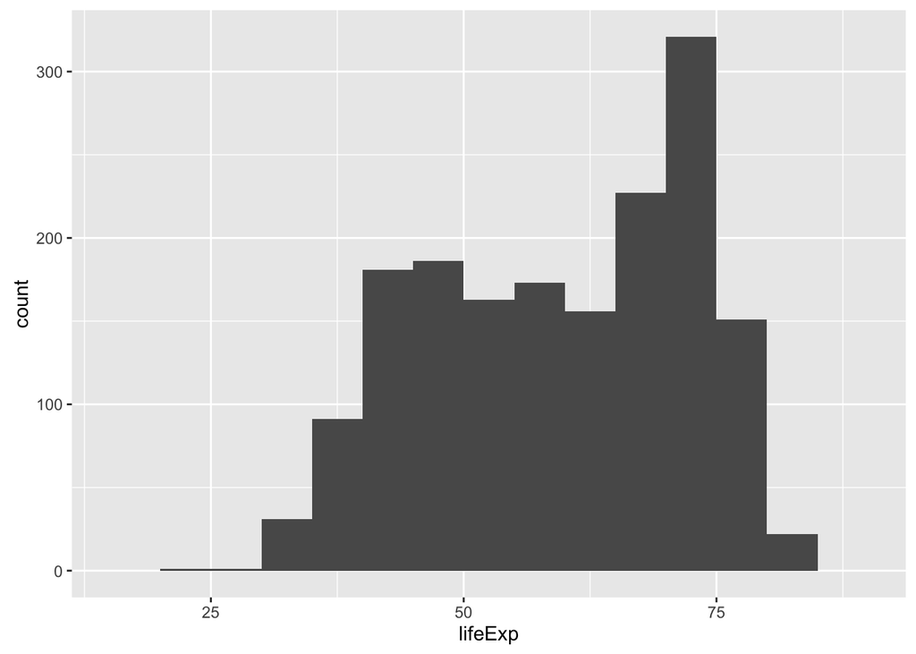

```r
ggplot(gapminder, aes(x = lifeExp)) +
  geom_histogram(binwidth = 5)
```

You could also save the plot to a variable

```r
lifexp_plot <- ggplot(gapminder, aes(x = lifeExp)) +
  geom_histogram()
```

If you just enter the variable name in the console it will “print”" the object, which in this case, simply creates the plot:

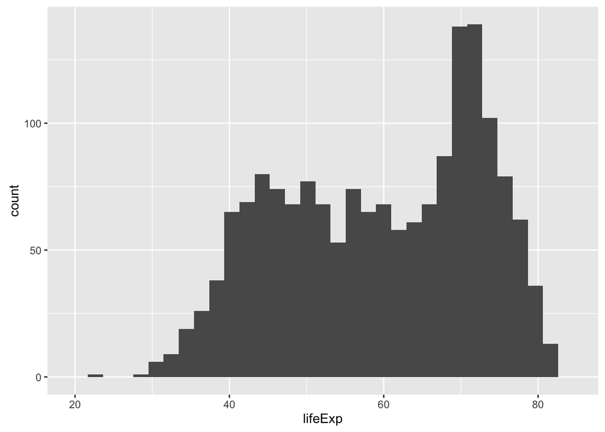

```r
lifexp_plot
```

To create a scatter plot of life expectancy vs. GDP per capita, we need both an `x` and `y` aesthetic, and we use the `geom_point` geom.

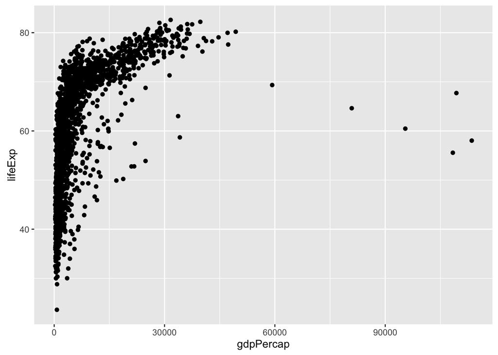

```r
ggplot(gapminder, aes(x = gdpPercap, y = lifeExp)) +
  geom_point()
```

However, the relationship between life expectancy and GDP per capita is clearer if plotted on a log-log scale. Lets use the variables, `log_gdp_per_cap` and `log_life_exp`, that we added to the `gapminder` dataset earlier in the lesson.

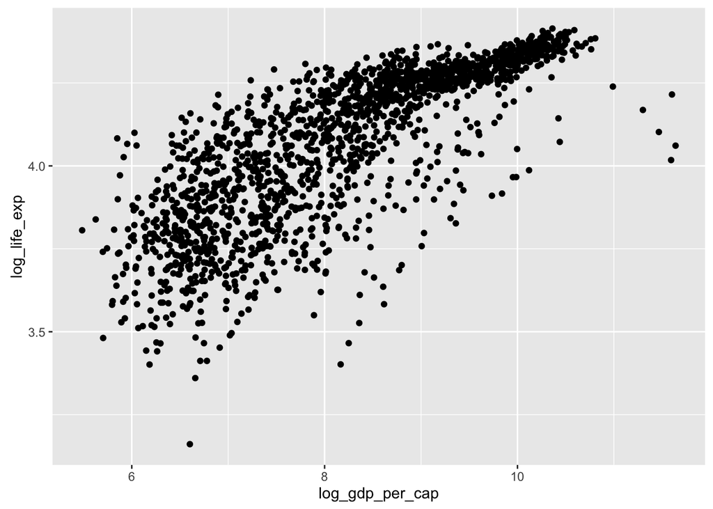

```r
ggplot(gapminder, aes(x = log_gdp_per_cap, y = log_life_exp)) +
  geom_point()
```

Now add titles to the plot and axis title,

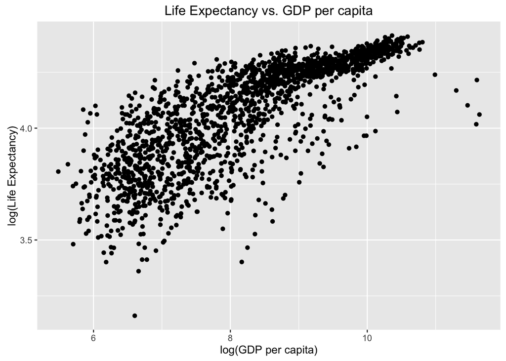

```r
ggplot(gapminder, aes(x = log_gdp_per_cap, y = log_life_exp)) +
  geom_point() +
  ggtitle("Life Expectancy vs. GDP per capita") +
  ylab("log(Life Expectancy)") +
  xlab("log(GDP per capita)")
```

To color points by continent, add the aesthetic `colour = continent`.

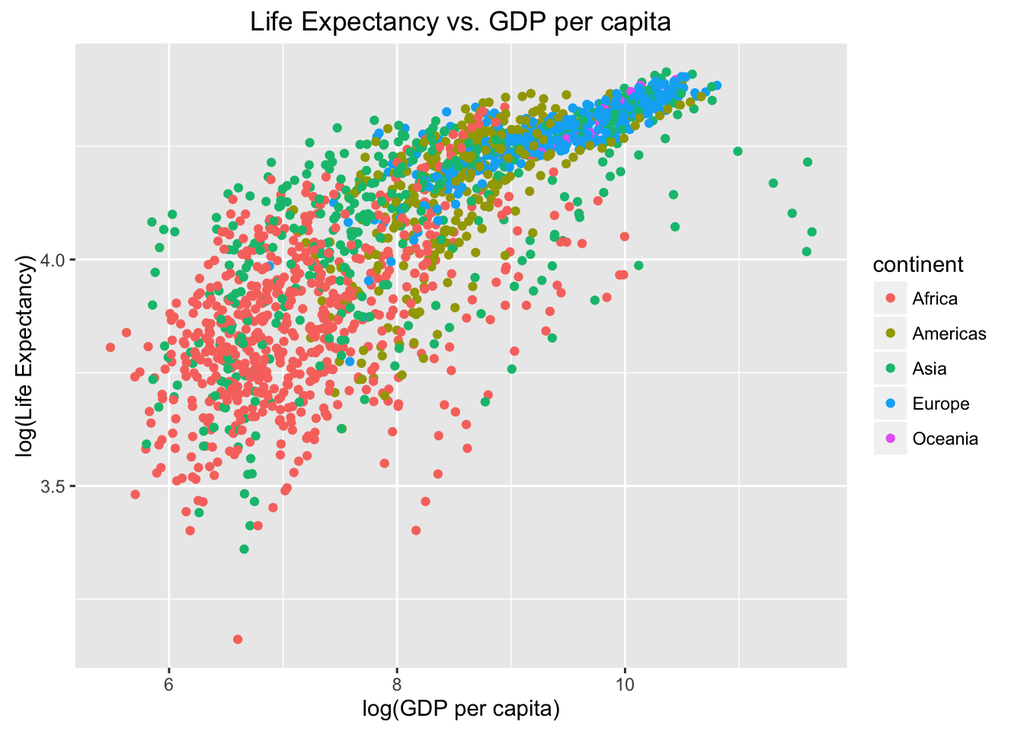

```r
ggplot(gapminder, aes(x = log_gdp_per_cap, y = log_life_exp,
                      colour = continent)) +
  geom_point() +
  ggtitle("Life Expectancy vs. GDP per capita") +
  ylab("log(Life Expectancy)") +
  xlab("log(GDP per capita)")
```

Instead, we could color the points by year,

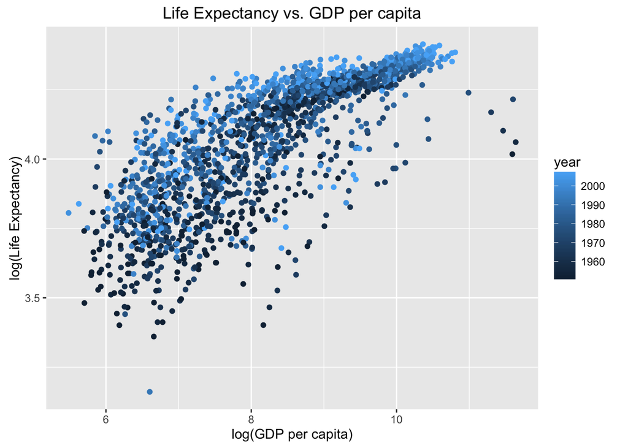

```r
ggplot(gapminder, aes(x = log_gdp_per_cap, y = log_life_exp,
                      colour = year)) +
  geom_point() +
  ggtitle("Life Expectancy vs. GDP per capita") +
  ylab("log(Life Expectancy)") +
  xlab("log(GDP per capita)")
```

Now size the points proportional to their population,

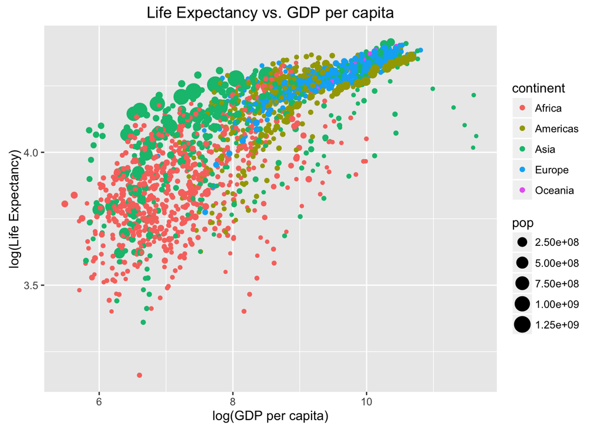

```r
ggplot(gapminder, aes(x = log_gdp_per_cap, y = log_life_exp,
                      colour = continent,
                      size = pop)) +
  geom_point() +
  ggtitle("Life Expectancy vs. GDP per capita") +
  ylab("log(Life Expectancy)") +
  xlab("log(GDP per capita)")
```

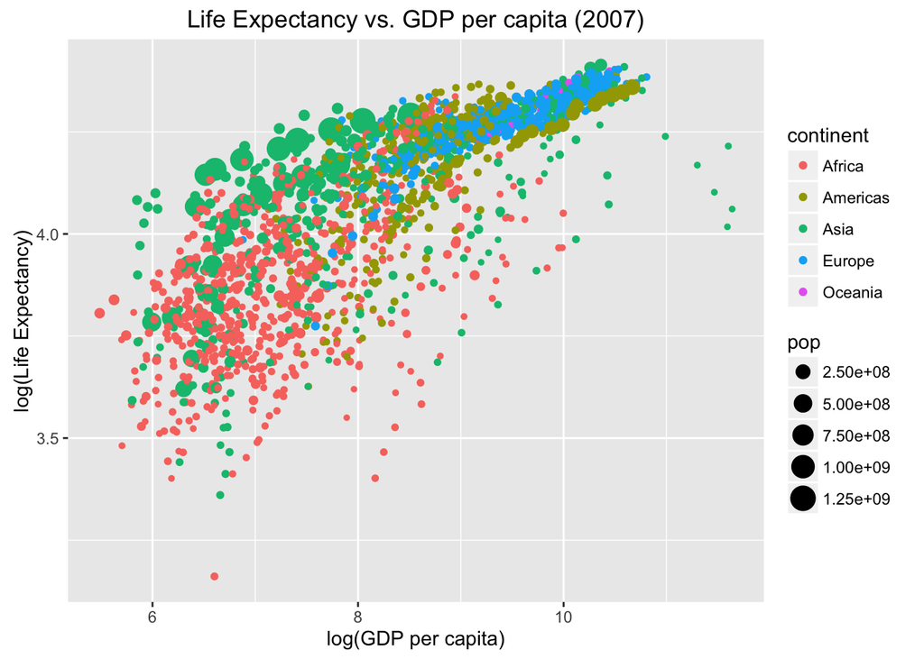

```r
gapminder2007 <- gapminder[gapminder$year == 2007, ]
ggplot(gapminder, aes(x = log_gdp_per_cap, y = log_life_exp,
                      colour = continent,
                      size = pop)) +
  geom_point() +
  ggtitle("Life Expectancy vs. GDP per capita (2007)") +
  ylab("log(Life Expectancy)") +
  xlab("log(GDP per capita)")
```

Even better, lets split up the plot into “facets” by year,

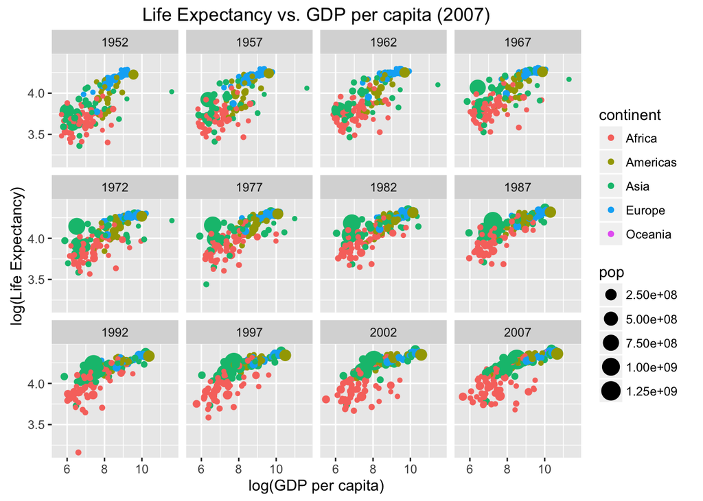

```r
ggplot(gapminder, aes(x = log_gdp_per_cap, y = log_life_exp,
                      colour = continent,
                      size = pop)) +
  geom_point() +
  facet_wrap(~year, nrow = 3) +
  ggtitle("Life Expectancy vs. GDP per capita (2007)") +
  ylab("log(Life Expectancy)") +
  xlab("log(GDP per capita)")
```

We will generally not use base R graphics in this course, instead relying on **gplot2**. Here is how a couple of those plots would be made using the base R graphics. For a histogram use the `hist` function:

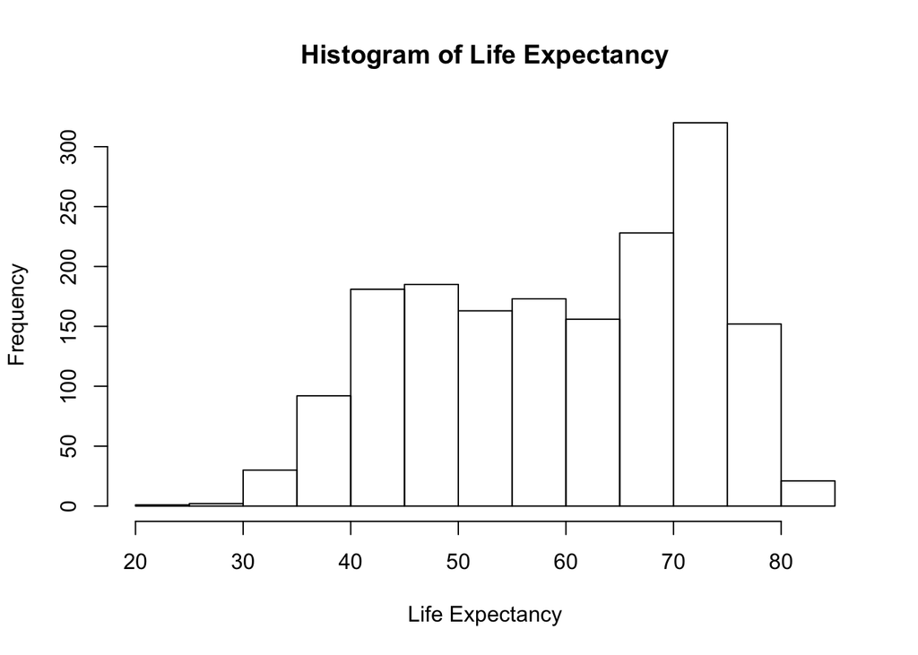

```r
hist(gapminder$lifeExp, main = "Histogram of Life Expectancy",
     xlab = "Life Expectancy")
```

For a scatter plot use the `plot` function:

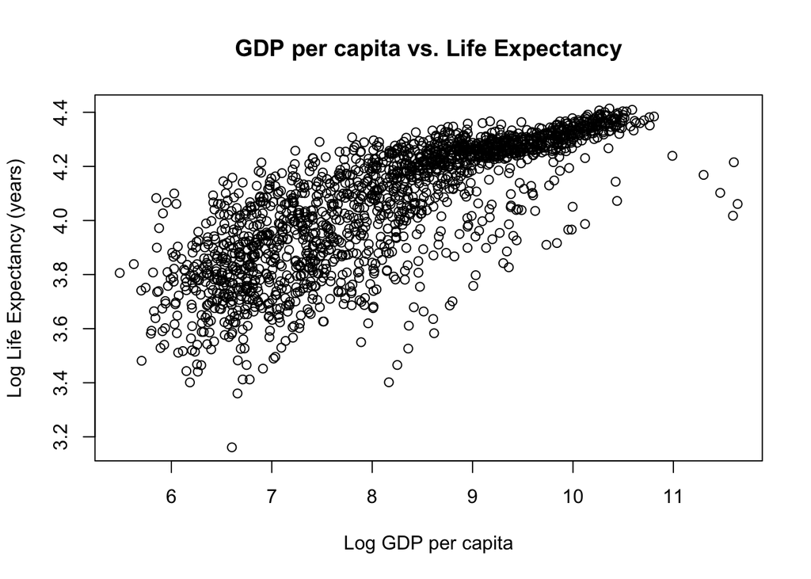

```r
plot(gapminder$log_gdp_per_cap, gapminder$log_life_exp,
     main = "GDP per capita vs. Life Expectancy",
     ylab = "Log Life Expectancy (years)",
     xlab = "Log GDP per capita")
```

For more on base graphics see the following sources, among others:

- [Quick R: Basic Graphics](http://www.statmethods.net/graphs/)
- [Base Graphics in R: A Detailed Idiot’s Guide](https://susanejohnston.wordpress.com/2013/08/30/base-graphics-in-r-a-detailed-idiots-guide/)
- Roger Peng [Exploratory Data Analysis with R](https://leanpub.com/exdata). Chapters “Plotting Systems”, “Graphics Devices”, “The Base Plotting System”, “Plotting and Color in R”.

This is derived from [R basics, workspace and working directory, RStudio projects](https://stat545-ubc.github.io/block002_hello-r-workspace-wd-project.html) ([CC BY-NC 3.0](http://creativecommons.org/licenses/by-nc/3.0/)).

[^1]: If you are curious as to why the variable was named `foo`, read [this](https://en.wikipedia.org/wiki/Foobar).

This work is licensed under a [Creative Commons Attribution-NonCommercial-ShareAlike 4.0 International License](http://creativecommons.org/licenses/by-nc-sa/4.0/). R code is licensed under a [BSD 2-clause](https://www.r-project.org/Licenses/BSD_2_clause) license.